# Barbell Lifting Quality Prediction Assignment

Chunhui Chen

August 22, 2016

# Summary

Using devices such as Jawbone Up, Nike FuelBand, and Fitbit it is now possible to collect a large amount of data about personal activity relatively inexpensively. These type of devices are part of the quantified self movement - a group of enthusiasts who take measurements about themselves regularly to improve their health, to find patterns in their behavior, or because they are tech geeks. One thing that people regularly do is quantify how much of a particular activity they do, but they rarely quantify how well they do it. In this project, our goal is to use the data(accelerometers on the belt, forearm, arm, and dumbell of 6 participants) to develope a model to predict the quality of the barbell lifts. The analysis has discovered that random forecast model is the most accurate model with accuracy of 99%.

# Loading And Processing Data

From the given data links, we download both the train and test datasets.

```r
trLink<-"https://d396qusza40orc.cloudfront.net/predmachlearn/pml-training.csv"
trainData<-read.csv(trLink,header=T, na.strings=c("NA", "#DIV/0!"))
teLink<-"https://d396qusza40orc.cloudfront.net/predmachlearn/pml-testing.csv"
testData<-read.csv(teLink,header=T, na.strings=c("NA", "#DIV/0!"))
dim(trainData);dim(testData)
```

```
## [1] 19622   160
```

```
## [1]  20 160
```

We then remove all columns that contains NA and remove features that are not in the testing dataset. The features containing NA are the variance, mean and standard devition within each window for each feature. Since the dataset is not time-dependence, these values can be disregarded. We will also remove the first 7 features since they are related to the time-series or are not numeric.

```r
features <- names(testData[,colSums(is.na(testData)) == 0])[-(1:7)]
trainData <- trainData[,c(features[-53],"classe")]
testData <- testData[,c(features[-53],"problem_id")]
dim(trainData);dim(testData)
```

```
## [1] 19622    53
```

```
## [1] 20 53
```

# Partitioning the Dataset

We split the training data into a training data set (70% of the total cases) and a testing data set (30% of the total cases). We can estimate the out of sample error of the predictor.

```r
library(caret);set.seed(888);
inTrain <- createDataPartition(trainData$classe, p=0.7, list=FALSE)
training <- trainData[inTrain,]
testing <- trainData[-inTrain,]
dim(training); dim(testing)
```

```
## [1] 13737    53
```

```
## [1] 5885   53
```

We got 13737 samples and 53 variables for training, 5885 samples and 53 variables for testing.

# Analysis

## Predicting With Decision Tree Model

```r
modFitDT <- rpart(classe ~ ., data = training, method="class")
prediction <- predict(modFitDT, testing, type = "class")
confusionMatrix(prediction, testing$class)
```

```
## Confusion Matrix and Statistics
##
##           Reference
## Prediction    A    B    C    D    E
##          A 1554  185   17   65   30
##          B   44  694   95   81   90
##          C   29   95  828  148  108
##          D   20   73   59  604   67
##          E   27   92   27   66  787
##
## Overall Statistics
##
##                Accuracy : 0.759
##                  95% CI : (0.7479, 0.7699)
##     No Information Rate : 0.2845
##     P-Value [Acc > NIR] : < 2.2e-16
##
##                   Kappa : 0.6941
##  Mcnemar's Test P-Value : < 2.2e-16
##
## Statistics by Class:
##
##                      Class: A Class: B Class: C Class: D Class: E
## Sensitivity            0.9283   0.6093   0.8070   0.6266   0.7274
## Specificity            0.9295   0.9347   0.9218   0.9555   0.9559
## Pos Pred Value         0.8395   0.6912   0.6854   0.7339   0.7878
## Neg Pred Value         0.9703   0.9088   0.9577   0.9289   0.9396
## Prevalence             0.2845   0.1935   0.1743   0.1638   0.1839
## Detection Rate         0.2641   0.1179   0.1407   0.1026   0.1337
## Detection Prevalence   0.3145   0.1706   0.2053   0.1398   0.1698
## Balanced Accuracy      0.9289   0.7720   0.8644   0.7910   0.8416
```

With 95% confidence, the accuracy of the fitted decision tree model is 76%. We then apply the decision tree model on the Testing Data(pml-testing.csv).

```r
predictionDT <- predict(modFitDT, testData, type = "class")
predictionDT
```

```
##  1  2  3  4  5  6  7  8  9 10 11 12 13 14 15 16 17 18 19 20
##  B  A  B  A  A  C  D  A  A  A  C  B  A  A  E  E  A  B  B  B
## Levels: A B C D E
```

## Predicting With Random Forest Model

```r
library(randomForest)
modFitRF <- randomForest(classe ~ ., data = training, ntree = 1000)
prediction <- predict(modFitRF, testing, type = "class")
confusionMatrix(prediction, testing$class)
```

```
## Confusion Matrix and Statistics
##
##           Reference
## Prediction    A    B    C    D    E
##          A 1674    8    0    0    0
##          B    0 1129    3    0    0
##          C    0    2 1023   11    0
##          D    0    0    0  953    4
##          E    0    0    0    0 1078
##
## Overall Statistics
##
##                Accuracy : 0.9952
##                  95% CI : (0.9931, 0.9968)
##     No Information Rate : 0.2845
##     P-Value [Acc > NIR] : < 2.2e-16
##
##                   Kappa : 0.994
##  Mcnemar's Test P-Value : NA
##
## Statistics by Class:
##
##                      Class: A Class: B Class: C Class: D Class: E
## Sensitivity            1.0000   0.9912   0.9971   0.9886   0.9963
## Specificity            0.9981   0.9994   0.9973   0.9992   1.0000
## Pos Pred Value         0.9952   0.9973   0.9875   0.9958   1.0000
## Neg Pred Value         1.0000   0.9979   0.9994   0.9978   0.9992
## Prevalence             0.2845   0.1935   0.1743   0.1638   0.1839
## Detection Rate         0.2845   0.1918   0.1738   0.1619   0.1832
## Detection Prevalence   0.2858   0.1924   0.1760   0.1626   0.1832
## Balanced Accuracy      0.9991   0.9953   0.9972   0.9939   0.9982
```

```r
predictionRF <- predict(modFitRF, testData, type = "class")
predictionRF
```

```
##  1  2  3  4  5  6  7  8  9 10 11 12 13 14 15 16 17 18 19 20
##  B  A  B  A  A  E  D  B  A  A  B  C  B  A  E  E  A  B  B  B
## Levels: A B C D E
```

# Conclusion

We can clearly see the accuracy of the random forest model is much better than the accuracy of the decision tree model when you look at the confusion matrix. So random forest model is a best model to predict the quality of barbell lifts.

# Appendix

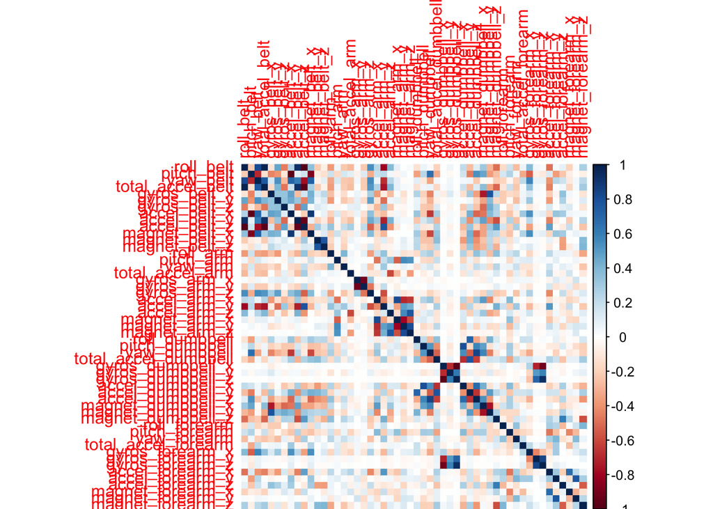

```r
library(corrplot)
corrPlot <- cor(trainData[, -length(names(trainData))])
corrplot(corrPlot, method="color")
```